Laboratorio histórico · Física atómica

# Experimento de la lámina de oro

Geiger y Marsden observaron cómo se dispersaban las partículas alfa; Rutherford explicó los resultados con un átomo casi vacío y un núcleo diminuto.

Ernest  
Rutherford

Hans  
Geiger

Ernest  
Marsden

FASE 01 · MONTAJERECONSTRUCCIÓN ESQUEMÁTICA

RITMO 1.0×ÁNGULO DE OBSERVACIÓN 120°

**0**PARTÍCULAS  
LANZADAS

**0**DESVIADAS  
EN EL MODELO

**0**GRAN ÁNGULO  
EN EL MODELO

### ¿Qué se observó?

La inmensa mayoría atravesó la lámina; una pequeña fracción se desvió y una proporción minúscula salió hacia atrás. Los destellos aparecían donde las partículas alfa alcanzaban la pantalla de sulfuro de zinc.

### La sorpresa de Rutherford

En 1911 interpretó las grandes desviaciones como choques con una región central muy pequeña, masiva y positiva. La carga positiva y casi toda la masa debían concentrarse en el núcleo.

### Un nuevo modelo… incompleto

El átomo nuclear desplazó al modelo de Thomson. No explicaba por sí solo la estabilidad de los electrones ni sus espectros: Bohr y la física cuántica desarrollarían después esas ideas.

**Espesor de referencia de la lámina:** aproximadamente 3.000–4.000 Å (0,3–0,4 μm); el valor variaba entre láminas. La geometría y las trayectorias están ampliadas. La pantalla curva representa el recorrido angular del detector; históricamente, la pequeña pantalla de ZnS iba unida al microscopio móvil. Los sucesos raros se hacen más frecuentes para poder verlos.

**Fuentes históricas, datos e imágenes**

La reconstrucción 3D toma como base la figura 1 del artículo de Geiger y Marsden de 1913. En esa figura se documentan la caja metálica cilíndrica B, la placa de vidrio esmerilado P, la plataforma graduada A, la junta estanca C, el tubo de vacío T, el soporte L, la fuente R, el diafragma D, la lámina F y el microscopio M con pantalla S. Las dimensiones completas y el acabado superficial no están especificados; esos detalles visuales son aproximaciones.

- [Geiger y Marsden (1909), «On a Diffuse Reflection of the α-Particles»](https://www.if.ufrj.br/~maximo/Lab-1_arquivos/Geiger-Marsden_Difusion-alfa-particles-1909.pdf): pantalla de ZnS observada al microscopio para contar las partículas reflejadas.
- [Geiger (1910), «The Scattering of the α-Particles by Matter»](https://royalsocietypublishing.org/doi/pdf/10.1098/rspa.1910.0038): primer montaje en tubo evacuado con fuente, lámina y pantalla al extremo.
- [Geiger y Marsden (1913), «The Laws of Deflexion of α Particles through Large Angles»](https://grundpraktikum.physik.uni-saarland.de/gpalt/Anleitungen/Ergaenzungen/J1_Papers/Rutherford%20-%20Geiger_Marsden.pdf): cámara cilíndrica evacuada; el microscopio y la pantalla se movían alrededor de la lámina para medir distintos ángulos.
- [Rutherford (1911), «The Scattering of α and β Particles by Matter and the Structure of the Atom»](https://www.lnl.infn.it/wp-content/uploads/Articolo_Rutherford_1911.pdf): interpretación teórica del núcleo.

**Espesor:** como orden de magnitud didáctico, una lámina de oro se cita a menudo en torno a 3.000–4.000 Å (0,3–0,4 μm). No fue un valor único: los artículos emplearon varios espesores y con frecuencia los expresaron por su poder de frenado.

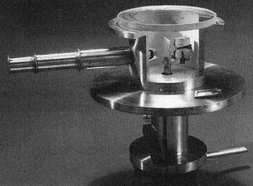

**Fotografía de referencia del aparato.** Imagen aportada por el usuario. Ha servido para ajustar la reconstrucción 3D: cámara cilíndrica vertical, bridas circulares, tubo de entrada lateral y pedestal. La escena es esquemática; el detector ZnS y su microscopio se representan en el interior de la cámara.